# Homework 5

Yanyu Chen

Assigned: 2021/11/24

### This homework is due before the next class. To complete this assignment, follow these steps:

This homework is designed to simulate full data analysis on example data sets. There is set up for both a regression and classification problem. The first is to find the best predictors for estimating body density in a dataset called “density.csv”. The vector body.density is the variable of interest in this data set.

## Problem 1: Exploring the data

### (1.1) Load the full `density.csv` data set for exploratory data analysis (EDA). Run the commands `str()` and `summary()` for the full data set. Build histograms for the age, weight, height and body.density vectors. Finally, create (3) x-y scatter plots for age, weight, height versus body.density (or use pairs). Which of these (3) variables, if any, appear to be good indicators of body.density?

```r
density <- read.csv("D:/Heinz/R Analytics/HW5/density.csv", stringsAsFactors=TRUE, encoding = "UTF-8")
colnames(density)[1] <- 'age'
```

```r
str(density)
```

```
## 'data.frame':    250 obs. of  14 variables:
##  $ age         : int  23 22 22 26 24 24 26 25 25 23 ...
##  $ weight      : num  154 173 154 185 184 ...
##  $ height      : num  67.8 72.2 66.2 72.2 71.2 ...
##  $ neck        : num  36.2 38.5 34 37.4 34.4 39 36.4 37.8 38.1 42.1 ...
##  $ chest       : num  93.1 93.6 95.8 101.8 97.3 ...
##  $ abdomen     : num  85.2 83 87.9 86.4 100 94.4 90.7 88.5 82.5 88.6 ...
##  $ hip         : num  94.5 98.7 99.2 101.2 101.9 ...
##  $ thigh       : num  59 58.7 59.6 60.1 63.2 66 58.4 60 62.9 63.1 ...
##  $ knee        : num  37.3 37.3 38.9 37.3 42.2 42 38.3 39.4 38.3 41.7 ...
##  $ ankle       : num  21.9 23.4 24 22.8 24 25.6 22.9 23.2 23.8 25 ...
##  $ biceps      : num  32 30.5 28.8 32.4 32.2 35.7 31.9 30.5 35.9 35.6 ...
##  $ forearm     : num  27.4 28.9 25.2 29.4 27.7 30.6 27.8 29 31.1 30 ...
##  $ wrist       : num  17.1 18.2 16.6 18.2 17.7 18.8 17.7 18.8 18.2 19.2 ...
##  $ body.density: num  1.07 1.09 1.04 1.08 1.03 ...
```

```r
summary(density)
```

```
##       age            weight          height           neck
##  Min.   :22.00   Min.   :118.5   Min.   :64.00   Min.   :31.10
##  1st Qu.:35.25   1st Qu.:158.5   1st Qu.:68.25   1st Qu.:36.40
##  Median :43.00   Median :176.1   Median :70.00   Median :38.00
##  Mean   :44.88   Mean   :178.1   Mean   :70.30   Mean   :37.94
##  3rd Qu.:54.00   3rd Qu.:196.8   3rd Qu.:72.25   3rd Qu.:39.40
##  Max.   :81.00   Max.   :262.8   Max.   :77.75   Max.   :43.90
##      chest           abdomen            hip             thigh
##  Min.   : 79.30   Min.   : 69.40   Min.   : 85.00   Min.   :47.20
##  1st Qu.: 94.25   1st Qu.: 84.53   1st Qu.: 95.50   1st Qu.:56.00
##  Median : 99.60   Median : 90.90   Median : 99.30   Median :58.95
##  Mean   :100.66   Mean   : 92.29   Mean   : 99.65   Mean   :59.25
##  3rd Qu.:105.30   3rd Qu.: 99.17   3rd Qu.:103.17   3rd Qu.:62.25
##  Max.   :128.30   Max.   :126.20   Max.   :125.60   Max.   :74.40
##       knee           ankle           biceps         forearm
##  Min.   :33.00   Min.   :19.10   Min.   :24.80   Min.   :21.00
##  1st Qu.:36.92   1st Qu.:22.00   1st Qu.:30.20   1st Qu.:27.30
##  Median :38.45   Median :22.80   Median :32.00   Median :28.70
##  Mean   :38.53   Mean   :23.07   Mean   :32.22   Mean   :28.66
##  3rd Qu.:39.88   3rd Qu.:24.00   3rd Qu.:34.30   3rd Qu.:30.00
##  Max.   :46.00   Max.   :33.90   Max.   :39.10   Max.   :34.90
##      wrist        body.density
##  Min.   :15.80   Min.   :0.995
##  1st Qu.:17.60   1st Qu.:1.042
##  Median :18.30   Median :1.055
##  Mean   :18.22   Mean   :1.056
##  3rd Qu.:18.80   3rd Qu.:1.070
##  Max.   :21.40   Max.   :1.109
```

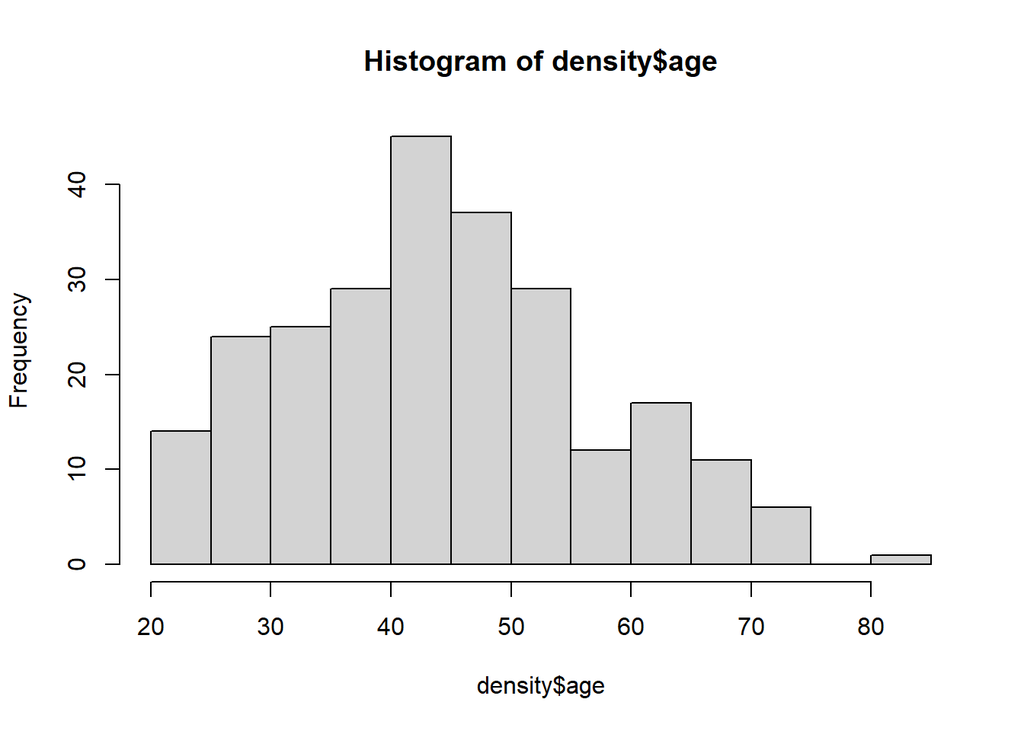

```r
# Plot the histograms
hist_age <- hist(density$age)
```

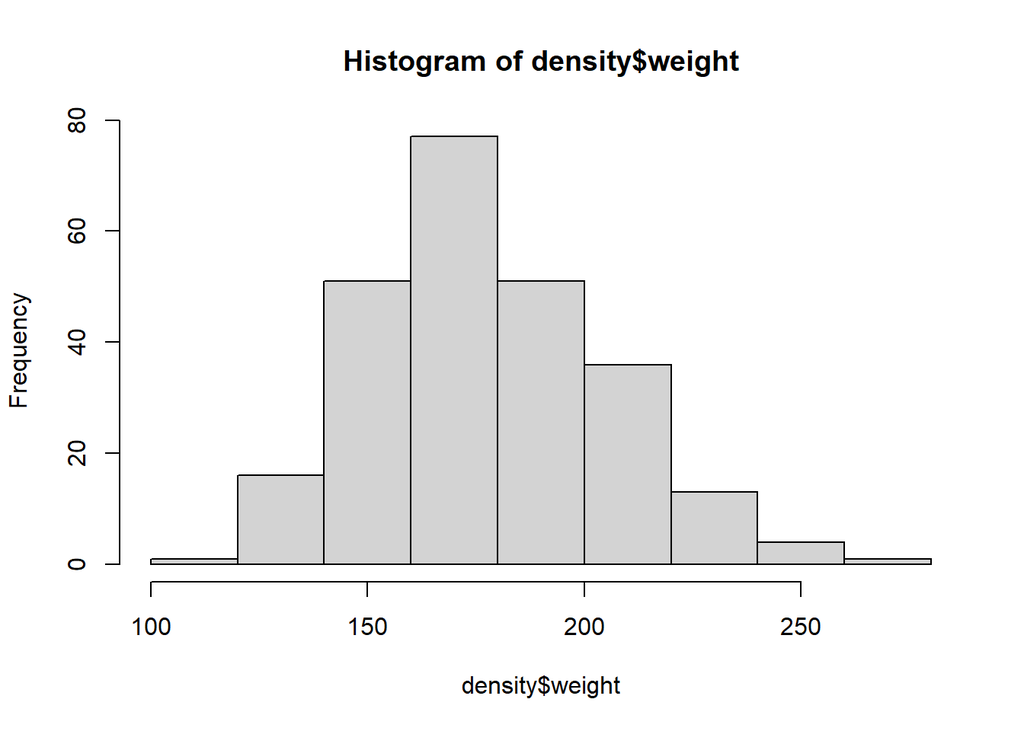

```r
hist_weight <- hist(density$weight)
```

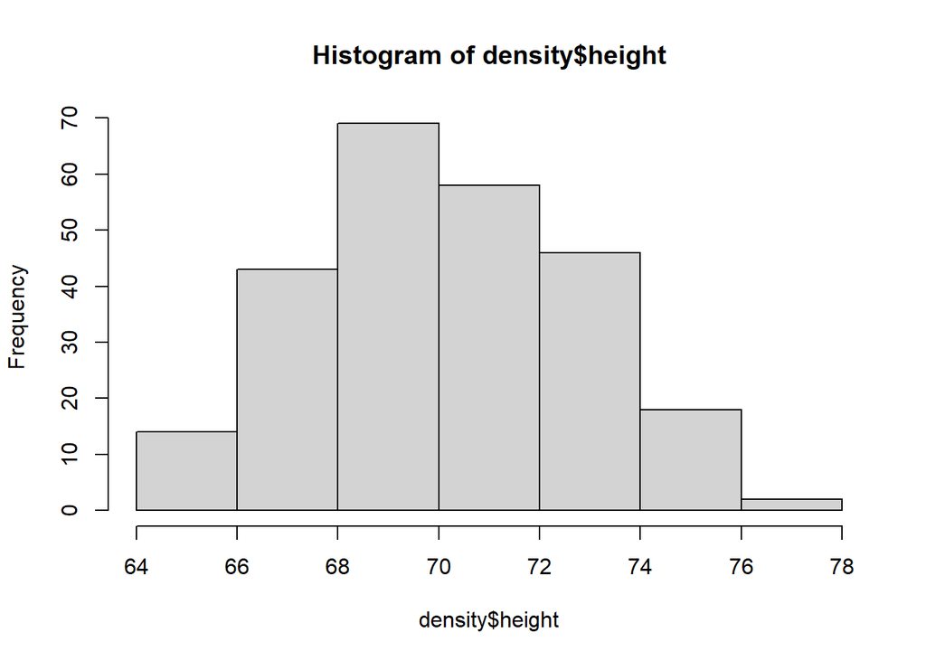

```r
hist_height <- hist(density$height)
```

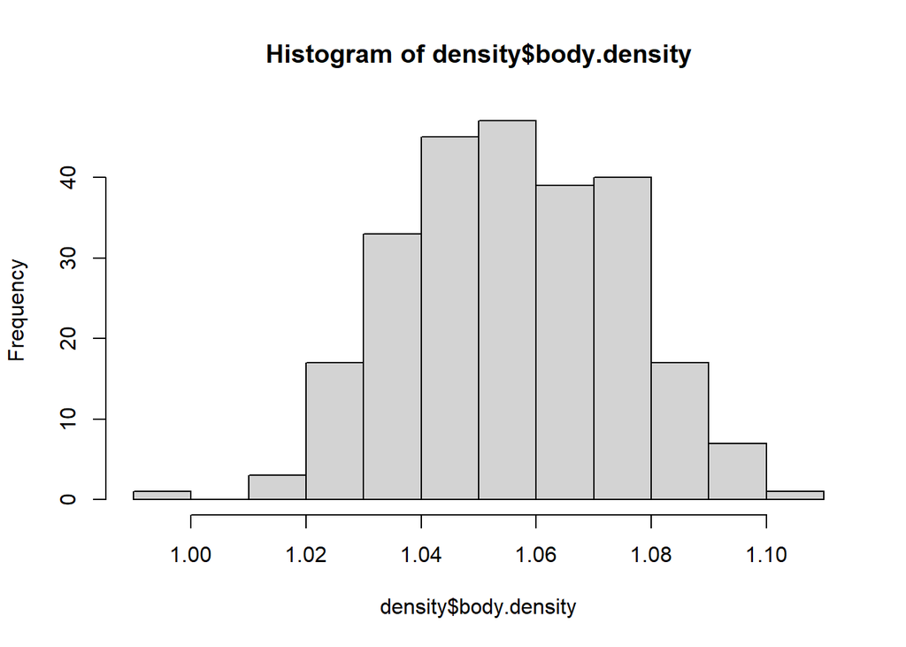

```r
hist_density <- hist(density$body.density)
```

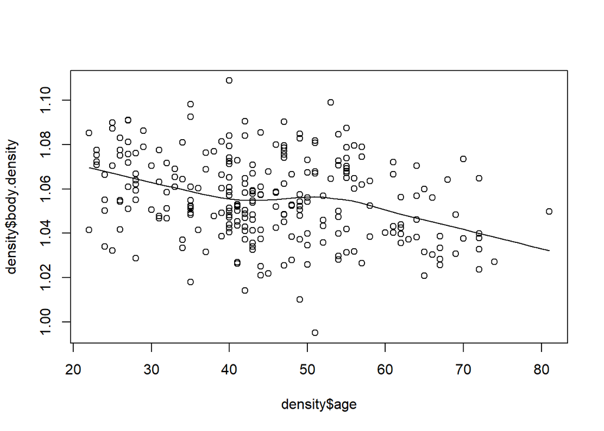

```r
# Edit me to create the scatterplots
scatter_age <- scatter.smooth(density$age, density$body.density)
```

```r
scatter_weight <- scatter.smooth(density$weight, density$body.density)
```

[figure not shown]

```r
scatter_height <- scatter.smooth(density$height, density$body.density)
```

[figure not shown]

## Problem 2: Corrleations

### (2.1) Evaluate the correlations between the variables. Which factors (up to 3) appear to be most strongly correlated with body.density?

```r
corr <- round(cor(density), 2)
corr
```

```
##                age weight height  neck chest abdomen   hip thigh  knee ankle
## age           1.00  -0.02  -0.25  0.12  0.18    0.24 -0.06 -0.22  0.02 -0.11
## weight       -0.02   1.00   0.51  0.81  0.89    0.87  0.93  0.85  0.84  0.58
## height       -0.25   0.51   1.00  0.32  0.22    0.19  0.40  0.35  0.51  0.39
## neck          0.12   0.81   0.32  1.00  0.77    0.73  0.71  0.67  0.65  0.43
## chest         0.18   0.89   0.22  0.77  1.00    0.91  0.82  0.71  0.70  0.45
## abdomen       0.24   0.87   0.19  0.73  0.91    1.00  0.86  0.74  0.71  0.41
## hip          -0.06   0.93   0.40  0.71  0.82    0.86  1.00  0.88  0.81  0.52
## thigh        -0.22   0.85   0.35  0.67  0.71    0.74  0.88  1.00  0.78  0.50
## knee          0.02   0.84   0.51  0.65  0.70    0.71  0.81  0.78  1.00  0.59
## ankle        -0.11   0.58   0.39  0.43  0.45    0.41  0.52  0.50  0.59  1.00
## biceps       -0.04   0.79   0.32  0.71  0.71    0.66  0.72  0.74  0.65  0.45
## forearm      -0.09   0.68   0.32  0.66  0.60    0.53  0.60  0.60  0.58  0.43
## wrist         0.22   0.73   0.40  0.73  0.64    0.60  0.63  0.54  0.66  0.54
## body.density -0.28  -0.60   0.04 -0.47 -0.68   -0.81 -0.62 -0.54 -0.48 -0.24
##              biceps forearm wrist body.density
## age           -0.04   -0.09  0.22        -0.28
## weight         0.79    0.68  0.73        -0.60
## height         0.32    0.32  0.40         0.04
## neck           0.71    0.66  0.73        -0.47
## chest          0.71    0.60  0.64        -0.68
## abdomen        0.66    0.53  0.60        -0.81
## hip            0.72    0.60  0.63        -0.62
## thigh          0.74    0.60  0.54        -0.54
## knee           0.65    0.58  0.66        -0.48
## ankle          0.45    0.43  0.54        -0.24
## biceps         1.00    0.70  0.61        -0.48
## forearm        0.70    1.00  0.60        -0.35
## wrist          0.61    0.60  1.00        -0.32
## body.density  -0.48   -0.35 -0.32         1.00
```

- the factors most closely correlated with body.density are abdomen, chest, and hip. Their absolute correlation values are higher than 0.6.

## Problem 3: t-tests and ANOVA

### (3.1) Recall the R command to test two means is `t.test()`, and `aov()` is the ANOVA function to test more than 2 means. Use these commands to test the means between the two vectors in the following examples: (a) the vectors `sleep.group1` and `sleep.group2` as created in the code chunk, below, at the standard 95% confidence level, (b) run an ANOVA test on the `InsectSpray` built-in dataset by spray type - this may take a bit of research to find the correct syntax, and (c) run an ANOVA test on the small dataset `runner.csv` available on Canvas (generate a base-R boxplot, if you would like to visualize the dataset - not a necessary part of the assignment).

```r
# Edit me to run t-test (a)
t.test(sleep.group1, sleep.group2, conf.level = 0.95)
```

```
##
##  Welch Two Sample t-test
##
## data:  sleep.group1 and sleep.group2
## t = -1.8608, df = 17.776, p-value = 0.07939
## alternative hypothesis: true difference in means is not equal to 0
## 95 percent confidence interval:
##  -3.3654832  0.2054832
## sample estimates:
## mean of x mean of y
##      0.75      2.33
```

```r
# Edit me to run ANOVA (b)
summary(InsectSprays)
```

```
##      count       spray
##  Min.   : 0.00   A:12
##  1st Qu.: 3.00   B:12
##  Median : 7.00   C:12
##  Mean   : 9.50   D:12
##  3rd Qu.:14.25   E:12
##  Max.   :26.00   F:12
```

```r
x1 <- InsectSprays[which(InsectSprays$spray == 'A'),1]
x2 <- InsectSprays[which(InsectSprays$spray == 'B'),1]
x3 <- InsectSprays[which(InsectSprays$spray == 'C'),1]
x4 <- InsectSprays[which(InsectSprays$spray == 'D'),1]
x5 <- InsectSprays[which(InsectSprays$spray == 'E'),1]
x6 <- InsectSprays[which(InsectSprays$spray == 'F'),1]

insect_df <- data.frame(cbind(x1, x2, x3, x4, x5, x6))
insect_to_anov <- stack(insect_df)
anov <- aov(values ~ ind, data = insect_to_anov)
summary(anov)
```

```
##             Df Sum Sq Mean Sq F value Pr(>F)
## ind          5   2669   533.8    34.7 <2e-16 ***
## Residuals   66   1015    15.4
## ---
## Signif. codes:  0 '***' 0.001 '**' 0.01 '*' 0.05 '.' 0.1 ' ' 1
```

```r
# Edit me to run ANOVA (c)
runner <- read.csv("D:/Heinz/R Analytics/HW5/runner.csv", stringsAsFactors=TRUE, encoding = "UTF-8")
colnames(runner)[1] <- 'trial'

x7 <- runner[which(runner$trial == 1),2]
x8 <- runner[which(runner$trial == 2),2]
x9 <- runner[which(runner$trial == 3),2]
x10 <- runner[which(runner$trial == 4),2]

runner_df <- data.frame(cbind(x7, x8, x9, x10))
runner_to_anov <- stack(runner_df)
anov2 <- aov(values ~ ind, data = runner_to_anov)
summary(anov2)
```

```
##             Df Sum Sq Mean Sq F value Pr(>F)
## ind          3  33943   11314   0.263   0.85
## Residuals    8 344249   43031
```

### (3.2) Comment on the outputs for each of the tests.

- fill in your comments about the statistical test results here:
  - the t test for (a) showed that these is no significant difference between the mean valueof sleep.group1 and sleep.group2.
  - the ANOVA test for (b) showed that there is(are) significant difference(s) between the mean counts of different sprays.
  - the t test for (c) showed that these is no significant difference between the mean distance of different trials.

## Problem 4: Linear models

### (4.1) Build two linear models `lm()` for the built-in `trees` dataset, comparing Height to Volume and Girth to Volume (2 seperate models). Also, plot each of these datasets (base-R is fine) and overlay the linear models with a red line on each of the 2 plots.

```r
# Build 2 linear models, evaluate the model results, and plot the datasets and superimpose the model line

# Volume ~ Height
trees_lm1 <- lm(Volume ~ Height, data = trees)
summary(trees_lm1)
```

```
##
## Call:
## lm(formula = Volume ~ Height, data = trees)
##
## Residuals:
##     Min      1Q  Median      3Q     Max
## -21.274  -9.894  -2.894  12.068  29.852
##
## Coefficients:
##             Estimate Std. Error t value Pr(>|t|)
## (Intercept) -87.1236    29.2731  -2.976 0.005835 **
## Height        1.5433     0.3839   4.021 0.000378 ***
## ---
## Signif. codes:  0 '***' 0.001 '**' 0.01 '*' 0.05 '.' 0.1 ' ' 1
##
## Residual standard error: 13.4 on 29 degrees of freedom
## Multiple R-squared:  0.3579, Adjusted R-squared:  0.3358
## F-statistic: 16.16 on 1 and 29 DF,  p-value: 0.0003784
```

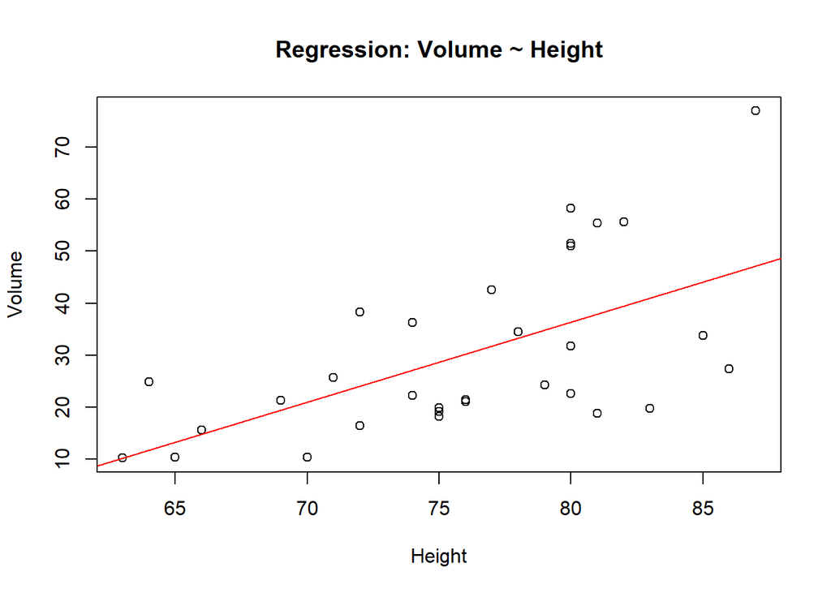

```
## integer(0)
```

```r
plot(x=trees$Height, y=trees$Volume, xlab='Height', ylab='Volume', main='Regression: Volume ~ Height') + abline(trees_lm1, col='red')
```

```r
# Volume ~ Girth
trees_lm2 <- lm(Volume ~ Girth, data = trees)
summary(trees_lm2)
```

```
##
## Call:
## lm(formula = Volume ~ Girth, data = trees)
##
## Residuals:
##    Min     1Q Median     3Q    Max
## -8.065 -3.107  0.152  3.495  9.587
##
## Coefficients:
##             Estimate Std. Error t value Pr(>|t|)
## (Intercept) -36.9435     3.3651  -10.98 7.62e-12 ***
## Girth         5.0659     0.2474   20.48  < 2e-16 ***
## ---
## Signif. codes:  0 '***' 0.001 '**' 0.01 '*' 0.05 '.' 0.1 ' ' 1
##
## Residual standard error: 4.252 on 29 degrees of freedom
## Multiple R-squared:  0.9353, Adjusted R-squared:  0.9331
## F-statistic: 419.4 on 1 and 29 DF,  p-value: < 2.2e-16
```

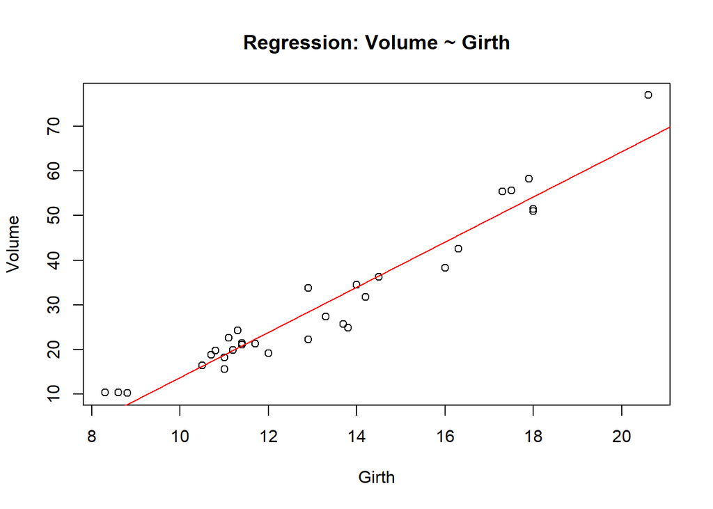

```
## integer(0)
```

```r
plot(x=trees$Girth, y=trees$Volume, xlab='Girth', ylab='Volume', main='Regression: Volume ~ Girth') + abline(trees_lm2, col='red')
```

### (4.2) Comment on the difference between the two. Does one of the two variables predict Volume better than the other and why? You may have multiple reasons to support your conclusions.

From the summaries for both regressions, we can see that the absolute t-statistic for the second regression is bigger, implying that the coefficient is more significant. Also, the R-square for the second regression ‘Volume ~ Girth’ is about 0.93, which is much more greater than R-square 0.34 of the first regression.

## Problem 5: Setting up a classification problem

### A rather “famous” dataset about diabetes in a population of Pima Indian women is available in a number of R libraries. *Please be sure to collect your dataset from the `faraway` package* (you may need to install this package if you do not have a copy already). Load the dataset `faraway::pima` as an object in your code below. Determine if any NAs exist in the dataset, and do some basic EDA (exploratory data analysis) on the variables. You do not need to run any classification models on this dataset, but you should note how the $test vector is either 0 or 1, indicating the absence or presence of the disease. Be sure to set this vactor as a factor. This problem is intentionally open-ended and an opportunity you you to use some thought and creativity in evaluating the dataset and preparing the target variable.

```r
# Overview the dataset
summary(pima)
```

```
##     pregnant         glucose        diastolic         triceps
##  Min.   : 0.000   Min.   :  0.0   Min.   :  0.00   Min.   : 0.00
##  1st Qu.: 1.000   1st Qu.: 99.0   1st Qu.: 62.00   1st Qu.: 0.00
##  Median : 3.000   Median :117.0   Median : 72.00   Median :23.00
##  Mean   : 3.845   Mean   :120.9   Mean   : 69.11   Mean   :20.54
##  3rd Qu.: 6.000   3rd Qu.:140.2   3rd Qu.: 80.00   3rd Qu.:32.00
##  Max.   :17.000   Max.   :199.0   Max.   :122.00   Max.   :99.00
##     insulin           bmi           diabetes           age
##  Min.   :  0.0   Min.   : 0.00   Min.   :0.0780   Min.   :21.00
##  1st Qu.:  0.0   1st Qu.:27.30   1st Qu.:0.2437   1st Qu.:24.00
##  Median : 30.5   Median :32.00   Median :0.3725   Median :29.00
##  Mean   : 79.8   Mean   :31.99   Mean   :0.4719   Mean   :33.24
##  3rd Qu.:127.2   3rd Qu.:36.60   3rd Qu.:0.6262   3rd Qu.:41.00
##  Max.   :846.0   Max.   :67.10   Max.   :2.4200   Max.   :81.00
##       test
##  Min.   :0.000
##  1st Qu.:0.000
##  Median :0.000
##  Mean   :0.349
##  3rd Qu.:1.000
##  Max.   :1.000
```

```r
# Convert the target variable into factor
pima$test <- as.factor(pima$test)

# Check nulls
sum(is.na(pima))
```

```
## [1] 0
```

```r
# EDA
str(pima)
```

```
## 'data.frame':    768 obs. of  9 variables:
##  $ pregnant : int  6 1 8 1 0 5 3 10 2 8 ...
##  $ glucose  : int  148 85 183 89 137 116 78 115 197 125 ...
##  $ diastolic: int  72 66 64 66 40 74 50 0 70 96 ...
##  $ triceps  : int  35 29 0 23 35 0 32 0 45 0 ...
##  $ insulin  : int  0 0 0 94 168 0 88 0 543 0 ...
##  $ bmi      : num  33.6 26.6 23.3 28.1 43.1 25.6 31 35.3 30.5 0 ...
##  $ diabetes : num  0.627 0.351 0.672 0.167 2.288 ...
##  $ age      : int  50 31 32 21 33 30 26 29 53 54 ...
##  $ test     : Factor w/ 2 levels "0","1": 2 1 2 1 2 1 2 1 2 2 ...
```

```r
head(pima)
```

```
##   pregnant glucose diastolic triceps insulin  bmi diabetes age test
## 1        6     148        72      35       0 33.6    0.627  50    1
## 2        1      85        66      29       0 26.6    0.351  31    0
## 3        8     183        64       0       0 23.3    0.672  32    1
## 4        1      89        66      23      94 28.1    0.167  21    0
## 5        0     137        40      35     168 43.1    2.288  33    1
## 6        5     116        74       0       0 25.6    0.201  30    0
```

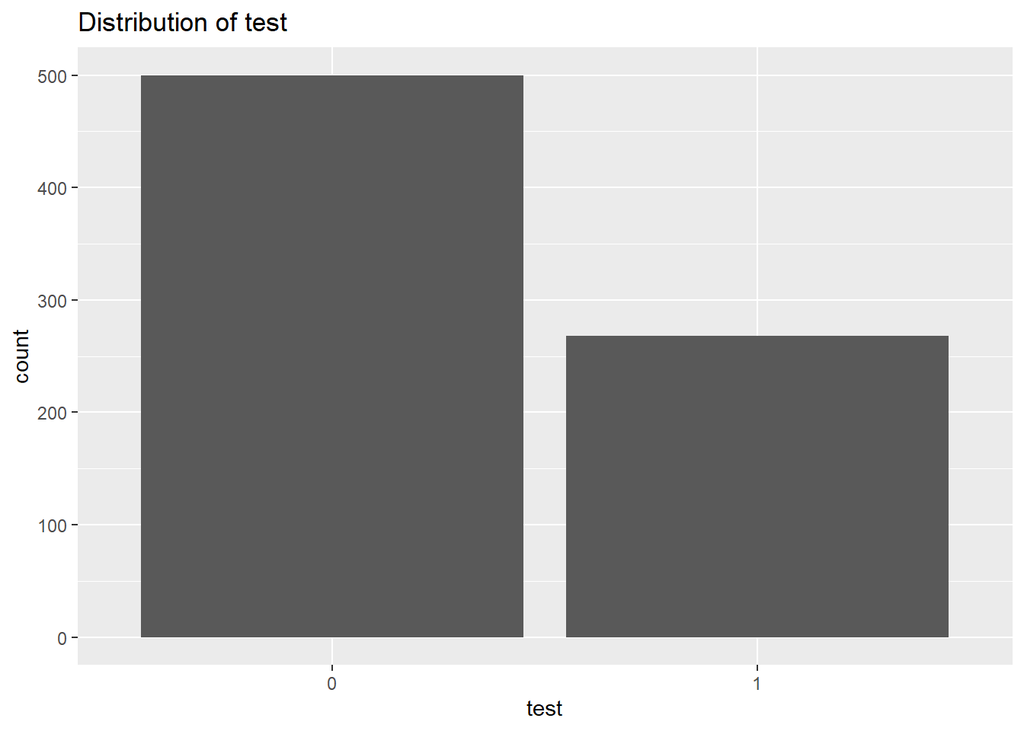

```r
ggplot(pima, aes(x = test)) + geom_bar() + labs(x='test') + ggtitle('Distribution of test')
```

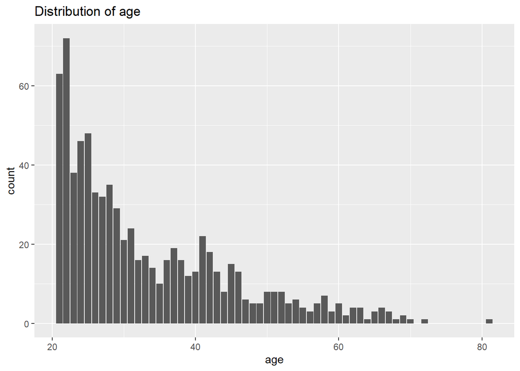

```r
ggplot(pima, aes(x = age)) + geom_bar() + labs(x='age') + ggtitle('Distribution of age')
```

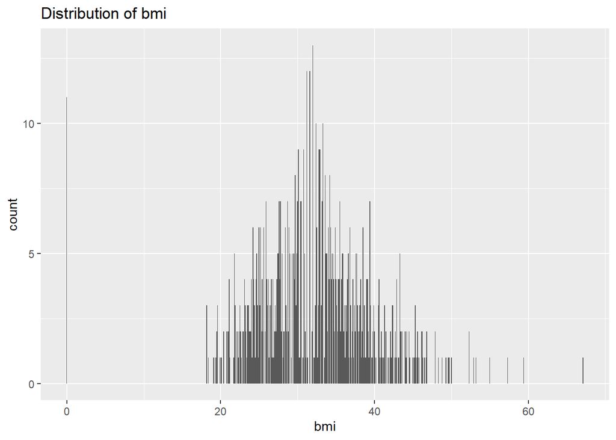

```r
ggplot(pima, aes(x = bmi)) + geom_bar() + labs(x='bmi') + ggtitle('Distribution of bmi') # Here we find there are zeros in bmi column
```

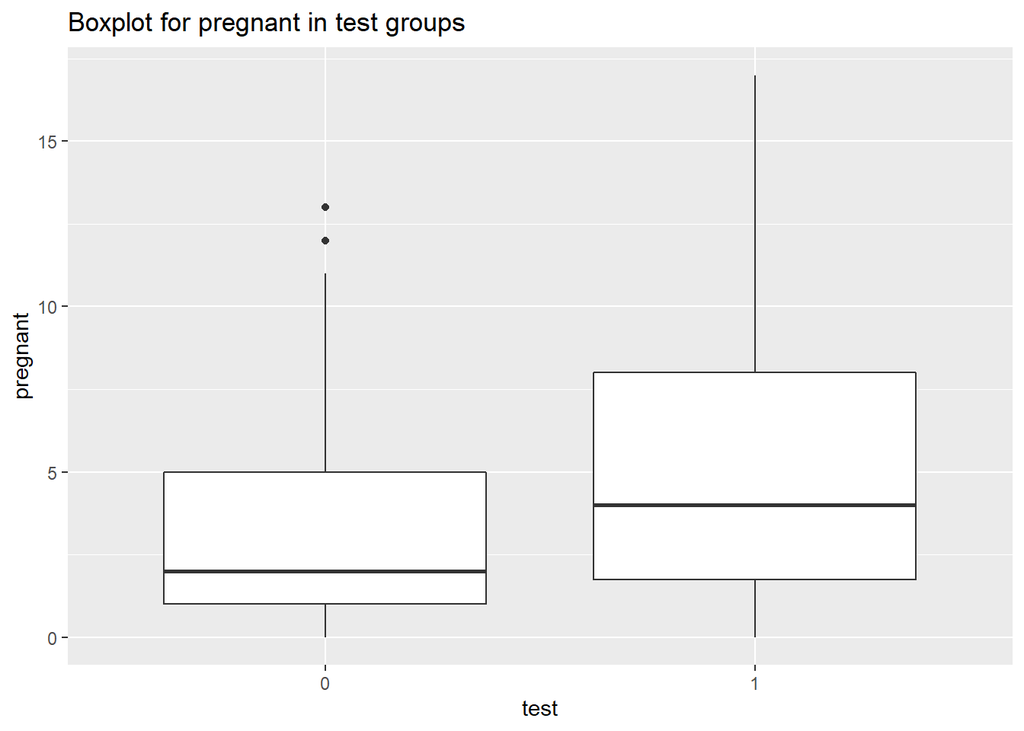

```r
# These three boxplots are some examples, we can do it with any other variables to check the outliers difference between groups.
ggplot(pima, aes(x=test, y=pregnant)) + geom_boxplot() + ggtitle('Boxplot for pregnant in test groups')
```

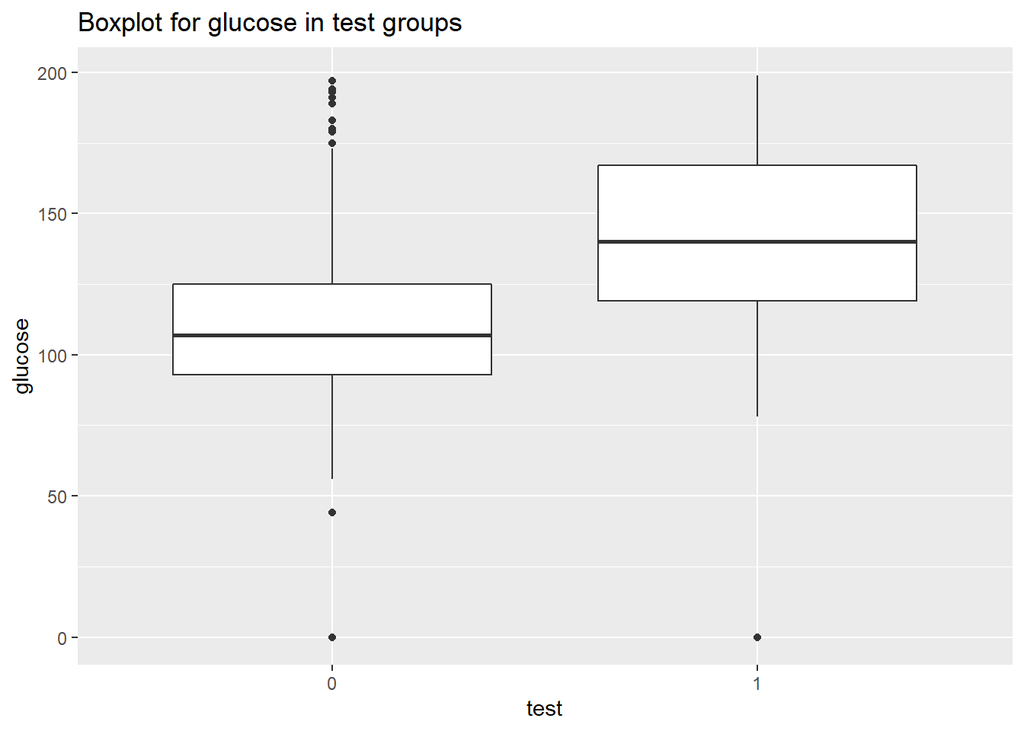

```r
ggplot(pima, aes(x=test, y=glucose)) + geom_boxplot() + ggtitle('Boxplot for glucose in test groups')
```

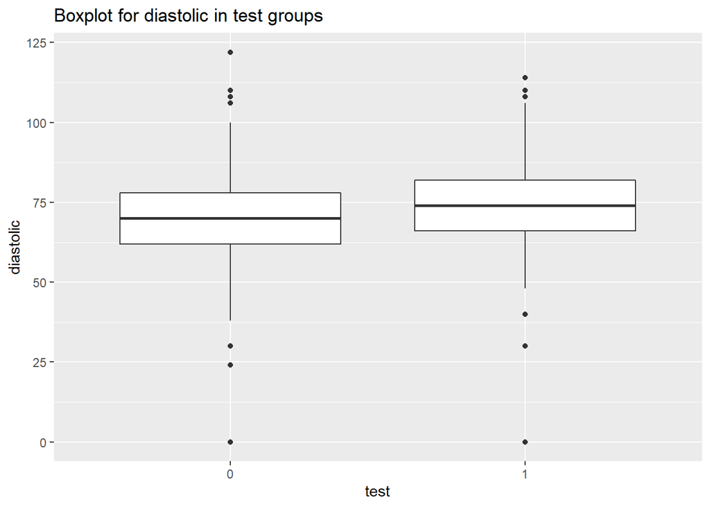

```r
ggplot(pima, aes(x=test, y=diastolic)) + geom_boxplot() + ggtitle('Boxplot for diastolic in test groups')
```

```r
# We can use the KNN to make classification of test.
pima_backup <- pima # Make a backup of the original dataset
pima <- subset(pima, bmi!=0) # Drop some invalid rows since BMI is not possible to be 0. We may need to make some similar adjustments if there are other invalid values.

inTrain <- createDataPartition(y = pima$test, p = 0.7, list = FALSE)
training <- pima[inTrain, ]
testing <- pima[-inTrain, ]

count(training)
```

```
##     n
## 1 531
```

```r
count(testing)
```

```
##     n
## 1 226
```

```r
# We don't need to run any classification models so it stops here.
```

### As usual, please complete, knit and save your homework in html, be sure your name is in the YAML header, and submit on Canvas before next week’s class.